# Applications of Inference Frameworks

Last updated: 2017-01-31

## Notes

## Readings

## Three frameworks for inference

1. Analytical
2. Maximum likelihood
3. Bayesian

## Linear regression

What values of \(\theta_1\) and \(\theta_2\) provide the best fit line through \(Y\) as a function of \(X\)?

\[Y = \theta_1 + \theta_2 X\]

How do we estimate \(\theta_1\) and \(\theta_2\)?

## Generate data

Generate \(n=30\) random data points: \(X \sim \mathcal{N}(10, 1)\) and \(Y = 2.3 X + \epsilon\), where \(\epsilon \sim \mathcal{N}(1, 1)\):

```r
set.seed(4)
n <- 30
X <- rnorm(n, mean = 10, sd = 1)
Y <- 2.3 * X + rnorm(n, mean = 1, sd = 1)
M <- data.frame(X, Y)
M %>% head()
```

```
##           X        Y
## 1 10.216755 24.65200
## 2  9.457507 23.80420
## 3 10.891145 25.29542
## 4 10.595981 23.88857
## 5 11.635618 28.62305
## 6 10.689275 25.18081
```

## Generate data

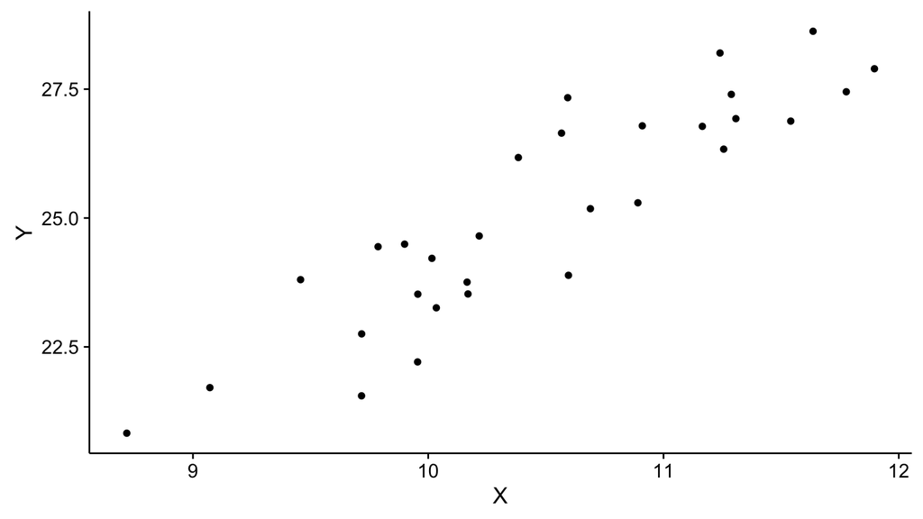

## Analytical solution 1

Sums of squares

## Analytical solution 2: Matrix algebra

\(Y\) is a (\(n \times 1\)) vector of observed values \(X\) is an (\(n \times 2\)) matrix of ones followed by observations

\[\theta = (X'X)^{-1} X'Y\]

Where \(X'\) is the transpose of \(X\) and \(X{-1}\) is the inverse.

```r
(X_mat <- matrix(c(rep(1, n), X), ncol = 2))
```

```
##       [,1]      [,2]
##  [1,]    1 10.216755
##  [2,]    1  9.457507
##  [3,]    1 10.891145
##  [4,]    1 10.595981
##  [5,]    1 11.635618
##  [6,]    1 10.689275
##  [7,]    1  8.718753
##  [8,]    1  9.786855
##  [9,]    1 11.896540
## [10,]    1 11.776863
## [11,]    1 10.566604
## [12,]    1 10.015719
## [13,]    1 10.383057
## [14,]    1  9.954863
```

[output cut: 16 more lines]

## Analytical solution 2

```r
(theta <- (solve(t(X_mat) %*% X_mat)) %*% (t(X_mat) %*% Y))
```

```
##             [,1]
## [1,] -0.03540546
## [2,]  2.39524849
```

`theta` is a 2 x 1 matrix of coefficients:

\[ \theta=\left[\begin{array}{c} -0.035\\ 2.395 \end{array}\right] \]

```r
lm_fast <- function(X, Y) {
  X_mat <- matrix(cbind(rep(1, length(Y)), X), nrow = length(Y))
  theta <- (solve(t(X_mat) %*% X_mat, tol = 1e-25)) %*% (t(X_mat) %*% Y)
  return(theta)
}

predict_Y <- function(theta, X) {
  X <- as.matrix(X, nrow = length(theta))
  Y_hat <- theta[1, 1] + rowSums(theta[2:nrow(theta), 1] * X)
  return(Y_hat)
}

log_lik <- function(Y, Y_hat) {
  var_hat <- sum((Y - Y_hat)^2) / (length(Y))
  sd_hat <- sqrt(var_hat)
  probs_Y <- dnorm(Y, mean = Y_hat, sd = sd_hat)
  LL <- sum(log(probs_Y))
  return(LL)
}
```

```r
theta <- lm_fast(X, Y)
Y_hat <- predict_Y(theta, X)
(LL <- log_lik(Y, Y_hat))
```

```
## [1] -40.25821
```

```r
fm <- lm(Y~X)
logLik(fm)
```

```
## 'log Lik.' -40.25821 (df=3)
```

```r
X_mat <- matrix(c(rep(1, length(X)), X), ncol = 2)
fm_fast <- fastLmPure(X_mat, as.matrix(Y))
log_lik(Y, fm_fast$fitted.values)
```

```
## [1] -40.25821
```

```r
t1 <- Sys.time()

reps <- 10^4
liks <- numeric(length = reps)

load("~/Dropbox/House/Aprob.rda")
n <- nrow(Aprob)

# Add column of 1's for intercept term
X <- as.matrix(cbind(rep(1, n), Aprob[, 2:9]), nrow = n)

set.seed(5)

for (i in 1:reps) {
  Y <- rexp(n, rate = 10)

  # Normalize so each row sums to 1.
  fm_fast <- fastLmPure(X, Y)
  liks[i] <- log_lik(Y, fm_fast$fitted.values)
}
Sys.time() - t1
```

```
## Time difference of 3.364937 secs
```

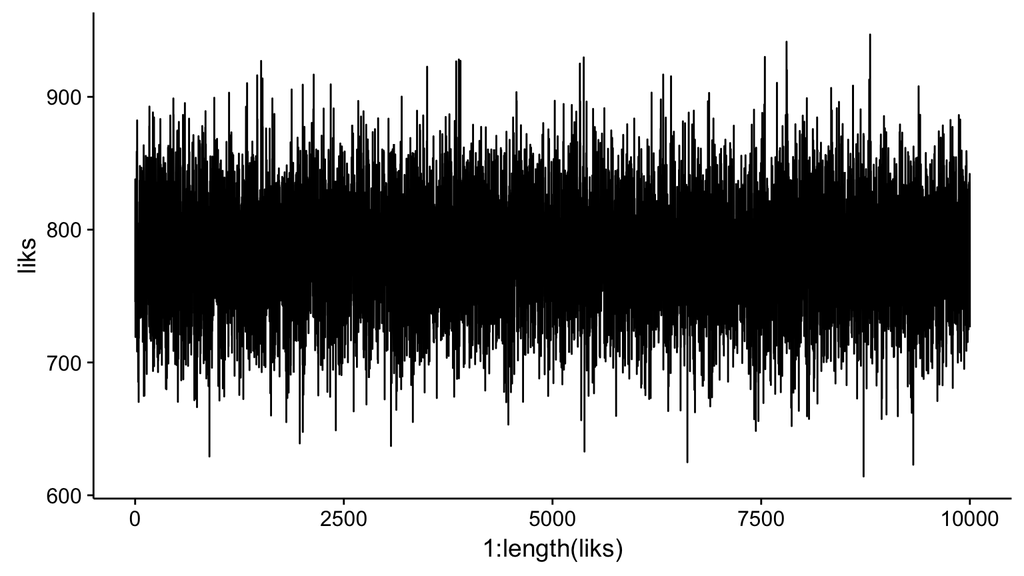

```r
ggplot(as.data.frame(liks), aes(x = 1:length(liks), y = liks)) +
  geom_path()
```

```r
library(modelr)
fm <- lm(Y ~ X, data = M)
M_aug <- M %>%
  add_residuals(fm) %>%
  add_predictions(fm)
M_aug
```

```
##            X        Y       resid     pred
## 1  10.216755 24.65200  0.21573922 24.43626
## 2   9.457507 23.80420  1.18652478 22.61767
## 3  10.891145 25.29542 -0.75617078 26.05159
## 4  10.595981 23.88857 -1.45603476 25.34460
## 5  11.635618 28.62305  0.78826234 27.83479
## 6  10.689275 25.18081 -0.38725166 25.56807
## 7   8.718753 20.82573 -0.02244801 20.84818
## 8   9.786855 24.44386  1.03731847 23.40655
## 9  11.896540 27.89615 -0.56361782 28.45976
## 10 11.776863 27.44924 -0.72386642 28.17311
## 11 10.566604 26.64690  1.37266101 25.27424
## 12 10.015719 24.21769  0.26295874 23.95473
## 13 10.383057 26.17354  1.33894731 24.83460
## 14  9.954863 22.20814 -1.60082873 23.80896
```

[output cut: 16 more lines]

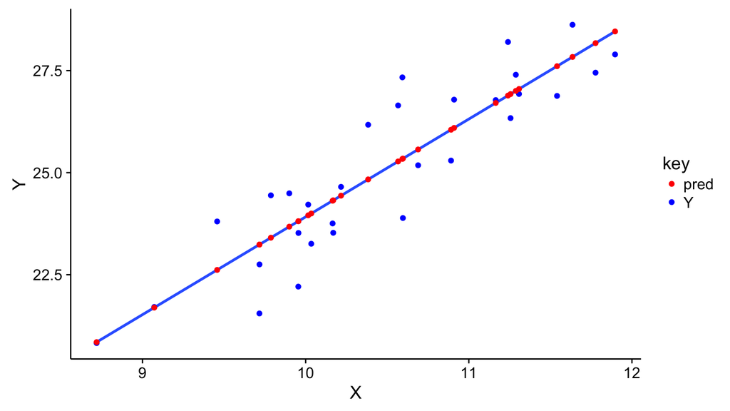

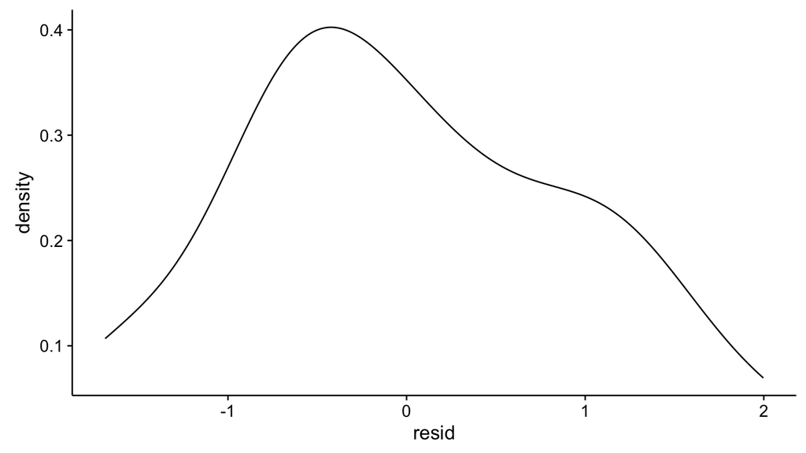

```
##     Min.  1st Qu.   Median     Mean  3rd Qu.     Max.
## -1.68700 -0.69020 -0.07185  0.00000  0.76430  1.99700
```

## Bayesian

What priors for intercept (\(\theta_0\)) and slope (\(\theta_1\))?

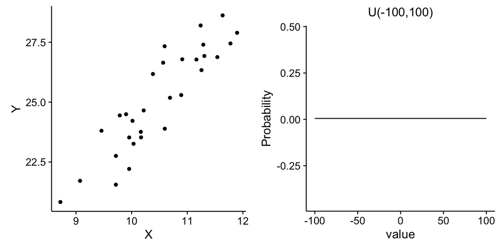

## Bayesian

```r
library(rethinking)

fm <- map2stan(
  alist(
    Y ~ dnorm(mu, sigma),
    mu <- theta_0 + theta_1 * X,
    theta_0 ~ dunif(-100, 100),
    theta_1 ~ dunif(-100, 100),
    sigma ~ dunif(0, 100)
  ),
  data = M,
  WAIC = FALSE,
  iter = 10^4
)
```

[output not shown]

## Bayesian

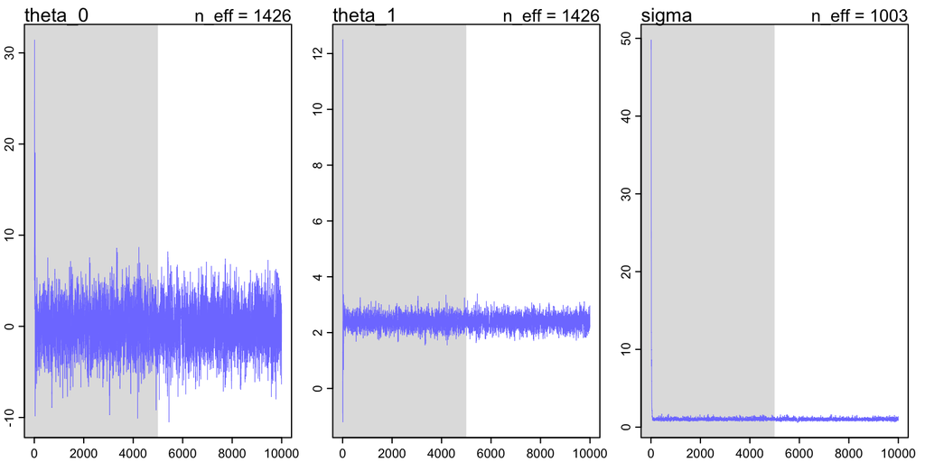

```r
plot(fm)
```

## Bayesian

```r
precis(fm, digits = 4)
```

```
##            Mean StdDev lower 0.89 upper 0.89 n_eff   Rhat
## theta_0 -0.0487 2.4384    -3.7649     3.9312  1426 1.0004
## theta_1  2.3968 0.2316     2.0188     2.7488  1426 1.0004
## sigma    0.9991 0.1434     0.7796     1.2227  1003 0.9998
```

```r
coef(lm(Y ~ X, data = M))
```

```
## (Intercept)           X
## -0.03540546  2.39524849
```

## Key features

- Analytical solutions are fast, hand-calculable
  - Unavailable for complex models (e.g., hierarchical models)
- Analytical and ML estimates will converge given enough precision
- Bayesian estimates can include prior knowledge
- ML and Bayesian estimates will converge for sufficiently flat priors